## Domain Report for December 15, 2019

### NOTE: These reports are still being developed!

There may be errors or inconsistencies in these reports– verify sensor issues with the SOM or other monitoring tools before putting in a trouble ticket. What are displayed as sensor failures or intermittent failures may instead be transient issues in streaming data. Please provide feedback on the reports on the [ServiceNow Blog](https://neon.service-now.com/community?id=community_blog&sys_id=9b4fbe8adbed734017ecf9041d9619be).

#### Future Improvements:

- The option to filter reports by system type
- Enhancements to detect issues based on coefficient of variation and range values are planned in the near future.

**KEY**:

- [Last date working*]; applicable only to assembly/sensor fails
- Assembly/Sensor Fail: <=5% uptime
- Intermittent Fail: >5% & <80% uptime

## D01

### HARV:

**Site outage or communications error**: - Check site status with the LC SoH tool: http://10.123.20.2/

### BART:

**Soil CO2 Concentration**: - Assembly failure at soil plot 1, depth 1 [2019-11-25*] - Intermittent assembly failure (21.5%) at soil plot 3, depth 3

### HOPB:

**Nitrate in Surface Water**: - Stream failure (*rawNitrateSingleCompressedStream*) at stream sensor location 2 [2019-12-06*]

**Specific Conductivity, Temperature, and Elevation of Groundwater**: - Assembly failure at ground water well 1 [2019-12-14*] - Intermittent assembly failure (7.4%) at ground water well 2 - Intermittent assembly failure (7.4%) at ground water well 3 - Intermittent assembly failure (7.4%) at ground water well 4

## D02

### SCBI:

**Soil Heat Flux**: - Assembly failure at soil plot 1, depth 1 [2019-10-19*]

### SERC:

**Atmospheric CO2 Isotope**: - Stream failure (*fwMoleCO2*) at hut [2019-12-14*] - Stream failure (*percentFwMoleH2O*) at hut [2019-12-14*] - Stream failure (*d13CO2*) at hut [2019-12-14*]

**Hut Environment**: - Intermittent assembly failure (29.5%) at hut

**ECSE profile sampling pump**: - Intermittent assembly failure (24.8%) at hut - Intermittent assembly failure (24.8%) at hut, ml-1 - Intermittent assembly failure (24.8%) at hut, ml-2 - Intermittent assembly failure (24.8%) at hut, ml-3 - Intermittent assembly failure (24.8%) at hut, ml-4 - Intermittent assembly failure (24.8%) at hut, ml-5 - Intermittent assembly failure (24.8%) at hut, ml-6

**Soil Temperature**: - Assembly failure at soil plot 3, depth 1 [>6 months ago*] - Assembly failure at soil plot 3, depth 2 [>6 months ago*] - Assembly failure at soil plot 3, depth 3 [>6 months ago*] - Assembly failure at soil plot 3, depth 4 [>6 months ago*] - Assembly failure at soil plot 3, depth 5 [>6 months ago*] - Assembly failure at soil plot 3, depth 6 [>6 months ago*]

**Soil CO2 Concentration**: - Assembly failure at soil plot 3, depth 1 [>6 months ago*] - Assembly failure at soil plot 3, depth 2 [>6 months ago*]

### BLAN:

*No alerts*

### LEWI:

*No alerts*

### POSE:

**Specific Conductivity, Temperature, and Elevation of Groundwater**: - Assembly failure at ground water well 6 [2019-12-09*]

## D03

### OSBS:

**Precipitation**: - Assembly failure at DFIR [2019-12-04*]

**Photosynthetically active radiation (Quantum Line)**: - Assembly failure at soil plot 1 [2019-11-22*] - Assembly failure at soil plot 3 [2019-12-04*]

**ECSE profile inlet pressure**: - Assembly failure at meas. level 5 [2019-12-02*]

**ECSE profile sampling pump**: - Assembly failure at hut [2019-12-02*] - Assembly failure at hut, ml-1 [2019-12-14*] - Assembly failure at hut, ml-2 [2019-12-14*] - Assembly failure at hut, ml-3 [2019-12-14*] - Assembly failure at hut, ml-4 [2019-12-14*] - Assembly failure at hut, ml-5 [2019-12-02*] - Assembly failure at hut, ml-6 [2019-12-14*]

**Soil Heat Flux**: - Calibration cycle not occurring regularly (CnC issue) at soil plot 5, depth 1- *(A spike in voltage every 3.25 hours, returning to 0, is the expected signal).* Current data pattern:

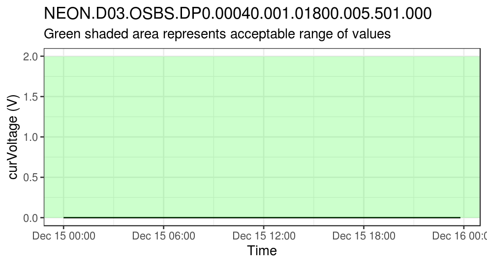

**Soil CO2 Concentration**: - Assembly failure at soil plot 1, depth 1 [2019-12-03*] - Assembly failure at soil plot 3, depth 3 [2019-12-02*] - Assembly failure at soil plot 4, depth 2 [2019-11-24*] - Assembly failure at soil plot 5, depth 3 [2019-11-23*]

### DSNY:

**Relative humidity**: - Assembly failure at soil plot 3 [2019-11-08*]

**Soil Temperature**: - Assembly failure at soil plot 4, depth 1 [>6 months ago*] - Assembly failure at soil plot 4, depth 2 [>6 months ago*] - Assembly failure at soil plot 4, depth 3 [>6 months ago*] - Assembly failure at soil plot 4, depth 4 [>6 months ago*] - Assembly failure at soil plot 4, depth 5 [>6 months ago*] - Assembly failure at soil plot 4, depth 6 [>6 months ago*]

**Soil CO2 Concentration**: - Assembly failure at soil plot 4, depth 1 [>6 months ago*] - Assembly failure at soil plot 4, depth 2 [>6 months ago*]

### JERC:

*No alerts*

### SUGG:

**Single Aspirated Air Temperature**: - Turbine broken or assembly inlet blocked at on-shore met station - Intermittent stream failure (*PRTResistance* at 38.8% uptime) at on-shore met station - Intermittent stream failure (*fanSpeed* at 38.8% uptime) at on-shore met station - Intermittent stream failure (*turbineSpeed* at 38.8% uptime) at on-shore met station

**Relative humidity**: - Intermittent assembly failure (38.8%) at on-shore met station

**Photosynthetically Active Radiation**: - Intermittent assembly failure (31%) at buoy - Assembly failure at lake inlet [2019-12-14*] - Intermittent assembly failure (31%) at lake outlet

**2D Wind Speed and Direction**: - Intermittent assembly failure (38.8%) at on-shore met station

**Barometric Pressure at lakes on-buoy**: - Intermittent assembly failure (38.8%) at buoy

**Nitrate in Surface Water**: - Intermittent stream failure (*rawNitrateSingleCompressedStream* at 38.8% uptime) at buoy

**Windspeed and direction on lakes on-buoy**: - Assembly failure at buoy [2019-12-02*]

**Temperature at Specific Depth in Lakes**: - Intermittent assembly failure (38.7%) at buoy

**Specific Conductivity, Temperature, and Elevation of Groundwater**: - Intermittent assembly failure (34.2%) at ground water well 1 - Intermittent assembly failure (34.2%) at ground water well 2 - Intermittent assembly failure (34.2%) at ground water well 3 - Intermittent assembly failure (34.2%) at ground water well 4 - Intermittent assembly failure (34.2%) at ground water well 5 - Intermittent assembly failure (34.2%) at ground water well 6 - Intermittent assembly failure (34.2%) at ground water well 7 - Intermittent assembly failure (34.2%) at ground water well 8

### BARC:

**Single Aspirated Air Temperature**: - Intermittent assembly failure (38.7%) at on-shore met station

**Relative humidity**: - Intermittent assembly failure (38.7%) at on-shore met station

**Photosynthetically Active Radiation**: - Intermittent assembly failure (38.2%) at buoy - Intermittent assembly failure (38.2%) at lake inlet - Intermittent assembly failure (38.2%) at lake outlet

**2D Wind Speed and Direction**: - Intermittent assembly failure (38.7%) at on-shore met station

**Barometric Pressure at lakes on-buoy**: - Intermittent assembly failure (38.7%) at buoy

**Photosynthetically Active Radiation at Water Surface**: - Intermittent stream failure (*inPAR* at 38.7% uptime) at buoy - Intermittent stream failure (*inPAR* at 37.4% uptime) at buoy - Intermittent stream failure (*inPAR* at 38.8% uptime) at buoy

**Nitrate in Surface Water**: - Stream failure (*rawNitrateSingleCompressedStream*) at buoy [2019-11-04*]

**Windspeed and direction on lakes on-buoy**: - Assembly failure at buoy [2019-12-07*]

**Water Quality**: - Intermittent assembly failure (38.9%) at buoy

**Temperature at Specific Depth in Lakes**: - Stream failure (*depth7WaterTemp*) at buoy [>6 months ago*] - Stream failure (*depth8WaterTemp*) at buoy [>6 months ago*] - Stream failure (*depth9WaterTemp*) at buoy [>6 months ago*] - Intermittent stream failure (*depth0WaterTemp* at 38.7% uptime) at buoy - Intermittent stream failure (*depth1WaterTemp* at 38.7% uptime) at buoy - Intermittent stream failure (*depth2WaterTemp* at 38.7% uptime) at buoy - Intermittent stream failure (*depth3WaterTemp* at 38.7% uptime) at buoy - Intermittent stream failure (*depth4WaterTemp* at 38.7% uptime) at buoy - Intermittent stream failure (*depth5WaterTemp* at 38.7% uptime) at buoy - Intermittent stream failure (*depth6WaterTemp* at 38.7% uptime) at buoy

**Specific Conductivity, Temperature, and Elevation of Groundwater**: - Intermittent assembly failure (38.9%) at ground water well 1 - Intermittent assembly failure (38.9%) at ground water well 2 - Intermittent assembly failure (38.9%) at ground water well 3 - Intermittent assembly failure (38.9%) at ground water well 4 - Intermittent assembly failure (38.9%) at ground water well 5 - Intermittent assembly failure (38.9%) at ground water well 6 - Intermittent assembly failure (38.9%) at ground water well 7 - Intermittent assembly failure (38.9%) at ground water well 8

### FLNT:

*No alerts*

## D04

### GUAN:

**2D Wind Speed and Direction**: - Assembly failure at meas. level 1 [2019-12-14*]

**ECSE profile sampling pump**: - Assembly failure at hut [2019-12-14*] - Assembly failure at hut, ml-1 [2019-12-14*] - Assembly failure at hut, ml-2 [2019-12-14*] - Assembly failure at hut, ml-3 [2019-12-14*] - Assembly failure at hut, ml-4 [2019-12-14*] - Assembly failure at hut, ml-5 [2019-12-14*]

**Soil Heat Flux**: - Calibration cycle not occurring regularly (CnC issue) at soil plot 3, depth 1- *(A spike in voltage every 3.25 hours, returning to 0, is the expected signal).* Current data pattern:

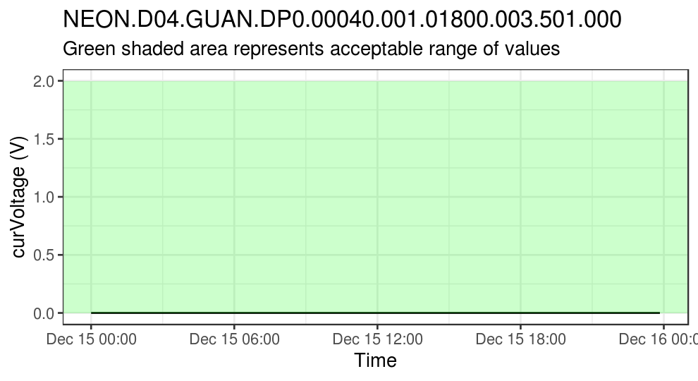

**Soil CO2 Concentration**: - Assembly failure at soil plot 4, depth 3 [2019-11-26*]

### LAJA:

*No alerts*

### CUPE:

**Elevation of surface water**: - Intermittent assembly failure (39.4%) at stream sensor location 2

**Nitrate in Surface Water**: - Stream failure (*rawNitrateSingleCompressedStream*) at stream sensor location 2 [2019-12-13*]

### GUIL:

**Nitrate in Surface Water**: - Stream failure (*rawNitrateSingleCompressedStream*) at stream sensor location 2 [2019-12-10*]

## D05

### UNDE:

**Single Aspirated Air Temperature**: - Assembly failure at meas. level 1 [2019-12-03*]

**2D Wind Speed and Direction**: - Assembly failure at meas. level 1 [2019-12-03*]

### TREE:

*No alerts*

### STEI:

*No alerts*

### CRAM:

**Specific Conductivity, Temperature, and Elevation of Groundwater**: - Assembly failure at ground water well 8 [2019-12-11*]

### LIRO:

*No alerts*

## D06

### UKFS:

**2D Wind Speed and Direction**: - Assembly failure at meas. level 5 [2019-11-27*]

**Soil Heat Flux**: - Calibration cycle not occurring regularly (CnC issue) at soil plot 5, depth 1- *(A spike in voltage every 3.25 hours, returning to 0, is the expected signal).* Current data pattern:

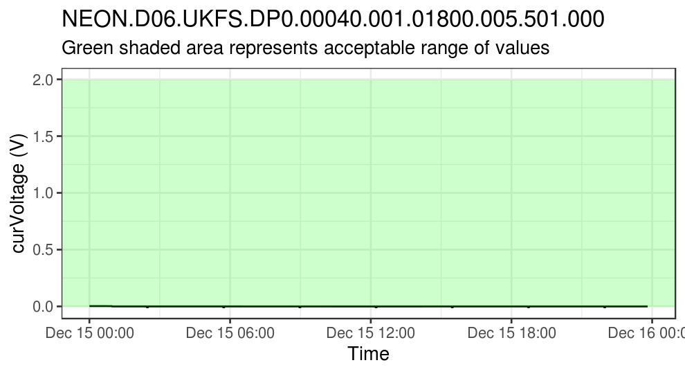

### KONZ:

**Soil CO2 Concentration**: - Assembly failure at soil plot 1, depth 2 [2019-10-31*]

### KONA:

**ECSE profile sampling pump**: - Intermittent assembly failure (49.6%) at hut, ml-1

**Soil Heat Flux**: - Calibration cycle not occurring regularly (CnC issue) at soil plot 3, depth 1- *(A spike in voltage every 3.25 hours, returning to 0, is the expected signal).* Current data pattern:

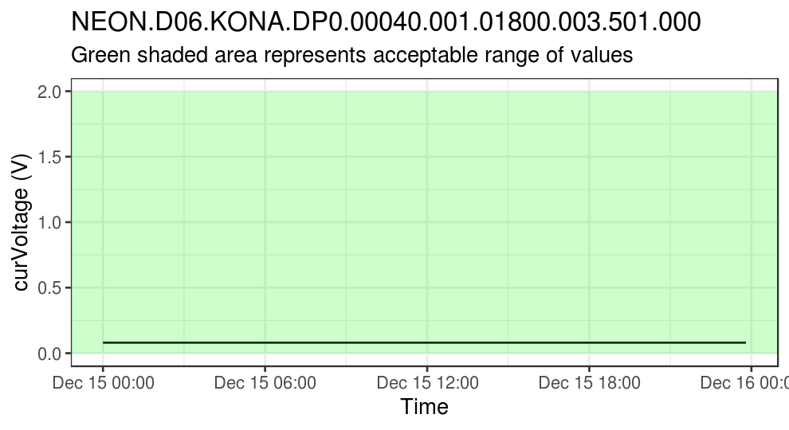

### KING:

*No alerts*

### MCDI:

*No alerts*

## D07

### ORNL:

*No alerts*

### MLBS:

**Relative humidity**: - Assembly failure at meas. level 6 [>6 months ago*]

**Soil Temperature**: - Assembly failure at soil plot 5, depth 1 [2019-12-06*] - Assembly failure at soil plot 5, depth 2 [2019-12-06*] - Assembly failure at soil plot 5, depth 3 [2019-12-06*] - Assembly failure at soil plot 5, depth 4 [2019-12-06*] - Assembly failure at soil plot 5, depth 5 [2019-12-06*] - Assembly failure at soil plot 5, depth 6 [2019-12-06*]

**Soil CO2 Concentration**: - Assembly failure at soil plot 5, depth 1 [2019-12-06*] - Assembly failure at soil plot 5, depth 2 [2019-12-06*]

### GRSM:

**ECSE profile sampling pump**: - Intermittent assembly failure (77.4%) at hut, ml-2

### LECO:

**Water Quality**: - Intermittent assembly failure (76.8%) at stream sensor location 2

### WALK:

**Specific Conductivity, Temperature, and Elevation of Groundwater**: - Assembly failure at ground water well 2 [2019-12-09*]

## D08

### TALL:

**2D Wind Speed and Direction**: - Assembly failure at meas. level 4 [2019-12-04*]

**ECSE profile CO2 & H2O concentration (storage)**: - Assembly failure at hut [2019-11-27*]

**ECSE profile sampling pump**: - Assembly failure at hut [2019-11-24*]

[figure not shown]

**Soil CO2 Concentration**: - Assembly failure at soil plot 4, depth 3 [2019-12-03*]

### LENO:

**Photosynthetically Active Radiation**: - Assembly failure at meas. level 2 [2019-10-25*] - Assembly failure at meas. level 3 [2019-10-25*]

**IR Biological Temperature**: - Assembly failure at meas. level 2 [2019-10-25*] - Assembly failure at meas. level 3 [2019-10-25*]

**ECSE profile sampling pump**: - Assembly failure at hut, ml-3 [2019-12-04*] - Assembly failure at hut, ml-4 [2019-12-04*]

**Soil Temperature**: - Assembly failure at soil plot 2, depth 7 [2019-11-20*] - Assembly failure at soil plot 2, depth 8 [2019-11-20*] - Assembly failure at soil plot 2, depth 9 [2019-11-20*] - Stream failure (*soilPRTResistance*) at soil plot 5, depth 9 [2019-11-20*]

**Soil CO2 Concentration**: - Assembly failure at soil plot 2, depth 3 [2019-11-06*]

### DELA:

**Single Aspirated Air Temperature**: - Assembly failure at meas. level 1 [2019-12-10*]

**Photosynthetically Active Radiation**: - Assembly failure at meas. level 1 [2019-12-10*]

**2D Wind Speed and Direction**: - Assembly failure at meas. level 1 [2019-12-10*]

**IR Biological Temperature**: - Assembly failure at meas. level 1 [2019-12-10*]

### BLWA:

**Temperature at Specific Depth in Lakes**: - Assembly failure at buoy [>6 months ago*]

**Specific Conductivity, Temperature, and Elevation of Groundwater**: - Assembly failure at ground water well 2 [2019-12-09*]

### MAYF:

**Specific Conductivity, Temperature, and Elevation of Groundwater**: - Assembly failure at ground water well 1 [2019-12-09*] - Assembly failure at ground water well 2 [2019-12-09*] - Assembly failure at ground water well 3 [2019-12-09*] - Assembly failure at ground water well 4 [2019-12-09*] - Assembly failure at ground water well 6 [2019-12-09*] - Intermittent assembly failure (7.2%) at ground water well 7 - Assembly failure at ground water well 8 [2019-12-09*]

### TOMB:

**Relative humidity**: - Assembly failure at buoy [2019-11-02*]

**Barometric Pressure at lakes on-buoy**: - Assembly failure at buoy [2019-11-02*]

**Photosynthetically Active Radiation at Water Surface**: - Stream failure (*inPAR*) at buoy [2019-10-04*]

**Nitrate in Surface Water**: - Stream failure (*rawNitrateSingleCompressedStream*) at buoy [2019-10-11*]

**Windspeed and direction on lakes on-buoy**: - Assembly failure at buoy [2019-11-02*]

**Water Quality**: - Assembly failure at buoy [2019-11-02*]

**Temperature at Specific Depth in Lakes**: - Assembly failure at buoy [2019-10-04*]

## D09

### WOOD:

**2D Wind Speed and Direction**: - Intermittent assembly failure (53.5%) at meas. level 1

### NOGP:

*No alerts*

### DCFS:

**2D Wind Speed and Direction**: - Assembly failure at meas. level 1 [2019-12-08*]

**Hut Environment**: - Assembly failure at hut [2019-12-09*]

**ECSE profile sampling pump**: - Assembly failure at hut, ml-3 [2019-12-09*]

### PRLA:

**Specific Conductivity, Temperature, and Elevation of Groundwater**: - Assembly failure at ground water well 8 [2019-12-09*]

### PRPO:

*No alerts*

## D10

### STER:

**ECSE profile CO2 & H2O concentration (storage)**: - Assembly failure at hut [2019-12-06*]

**ECSE profile sampling pump**: - Assembly failure at hut [2019-12-05*] - Assembly failure at hut, ml-1 [2019-12-06*]

**Particulate Mass**: - Assembly failure at meas. level 4 [2019-12-05*]

**Wet Depostion**: - Assembly failure at meas. level 4

**Soil Temperature**: - Assembly failure at soil plot 2, depth 1 [2019-12-11*] - Assembly failure at soil plot 2, depth 2 [2019-12-11*] - Assembly failure at soil plot 2, depth 3 [2019-12-11*] - Assembly failure at soil plot 2, depth 4 [2019-12-11*] - Assembly failure at soil plot 2, depth 5 [2019-12-11*] - Assembly failure at soil plot 2, depth 6 [2019-12-11*] - Assembly failure at soil plot 2, depth 7 [2019-12-11*] - Assembly failure at soil plot 2, depth 8 [2019-12-11*] - Assembly failure at soil plot 2, depth 9 [2019-12-11*]

**Soil CO2 Concentration**: - Assembly failure at soil plot 2, depth 1 [2019-12-11*] - Assembly failure at soil plot 2, depth 2 [2019-12-11*] - Assembly failure at soil plot 2, depth 3 [2019-12-11*] - Assembly failure at soil plot 3, depth 3 [2019-12-11*]

### RMNP:

**Single Aspirated Air Temperature**: - Intermittent assembly failure (26.6%) at meas. level 1 - Intermittent assembly failure (26.6%) at meas. level 2 - Fan broken at meas. level 3 - Stream failure (*PRTResistance*) at meas. level 3 [2019-11-13*] - Stream failure (*fanSpeed*) at meas. level 3 [2019-11-13*] - Stream failure (*turbineSpeed*) at meas. level 3 [2019-12-03*] - Assembly failure at meas. level 4 [2019-11-13*]

**Triple Aspirated Air Temperature**: - Assembly failure at meas. level 5 [2019-12-13*]

**Relative humidity**: - Intermittent assembly failure (46%) at meas. level 5 - Intermittent assembly failure (46%) at soil plot 3

**ECSE profile mass flow meter**: - Zero flow at hut, ml-1 - Intermittent stream failure (*frt0* at 50.2% uptime) at hut, ml-1 - Intermittent stream failure (*frt0* at 50.4% uptime) at hut, ml-1 - Intermittent stream failure (*frt0* at 50.1% uptime) at hut, ml-1 - Intermittent stream failure (*presAtm* at 50.2% uptime) at hut, ml-1 - Intermittent stream failure (*presAtm* at 50.4% uptime) at hut, ml-1 - Intermittent stream failure (*presAtm* at 50.1% uptime) at hut, ml-1 - Zero flow at hut, ml-2 - Intermittent stream failure (*frt0* at 50.2% uptime) at hut, ml-2 - Intermittent stream failure (*frt0* at 50.4% uptime) at hut, ml-2 - Intermittent stream failure (*frt0* at 50.1% uptime) at hut, ml-2 - Intermittent stream failure (*presAtm* at 50.2% uptime) at hut, ml-2 - Intermittent stream failure (*presAtm* at 50.4% uptime) at hut, ml-2 - Intermittent stream failure (*presAtm* at 50.1% uptime) at hut, ml-2 - Zero flow at hut, ml-3 - Intermittent stream failure (*frt0* at 50.2% uptime) at hut, ml-3 - Intermittent stream failure (*frt0* at 50.4% uptime) at hut, ml-3 - Intermittent stream failure (*frt0* at 50.1% uptime) at hut, ml-3 - Intermittent stream failure (*presAtm* at 50.2% uptime) at hut, ml-3 - Intermittent stream failure (*presAtm* at 50.4% uptime) at hut, ml-3 - Intermittent stream failure (*presAtm* at 50.1% uptime) at hut, ml-3 - Zero flow at hut, ml-4 - Intermittent stream failure (*frt0* at 50.2% uptime) at hut, ml-4 - Intermittent stream failure (*frt0* at 50.4% uptime) at hut, ml-4 - Intermittent stream failure (*frt0* at 50.1% uptime) at hut, ml-4 - Intermittent stream failure (*presAtm* at 50.2% uptime) at hut, ml-4 - Intermittent stream failure (*presAtm* at 50.4% uptime) at hut, ml-4 - Intermittent stream failure (*presAtm* at 50.1% uptime) at hut, ml-4 - Zero flow at hut, ml-5 - Intermittent stream failure (*frt0* at 50.2% uptime) at hut, ml-5 - Intermittent stream failure (*frt0* at 50.4% uptime) at hut, ml-5 - Intermittent stream failure (*frt0* at 50.1% uptime) at hut, ml-5 - Intermittent stream failure (*presAtm* at 50.2% uptime) at hut, ml-5 - Intermittent stream failure (*presAtm* at 50.4% uptime) at hut, ml-5 - Intermittent stream failure (*presAtm* at 50.1% uptime) at hut, ml-5

**ECSE profile mass flow controller (sampling)**: - Intermittent assembly failure (50.2%) at hut

**Photosynthetically active radiation (Quantum Line)**: - Intermittent assembly failure (50.2%) at soil plot 1 - Intermittent assembly failure (50.2%) at soil plot 3 - Intermittent assembly failure (50.2%) at soil plot 5

**Photosynthetically Active Radiation**: - Intermittent assembly failure (25.1%) at meas. level 1 - Intermittent assembly failure (25.1%) at meas. level 2 - Intermittent assembly failure (25.1%) at meas. level 3 - Assembly failure at meas. level 4 [2019-12-03*] - Assembly failure at meas. level 5 [2019-12-13*]

**2D Wind Speed and Direction**: - Intermittent assembly failure (40.1%) at meas. level 1 - Intermittent assembly failure (40.1%) at meas. level 2 - Intermittent assembly failure (40.1%) at meas. level 3 - Assembly failure at meas. level 4 [2019-11-13*]

**Atmospheric CO2 Isotope**: - Intermittent stream failure (*fwMoleCO2* at 51.6% uptime) at hut - Intermittent stream failure (*fwMoleCO2* at 49.1% uptime) at hut - Intermittent stream failure (*percentFwMoleH2O* at 51.6% uptime) at hut - Intermittent stream failure (*d13CO2* at 51.6% uptime) at hut

**ECSE profile CO2 & H2O concentration (storage)**: - Intermittent assembly failure (49.9%) at hut

**IR Biological Temperature**: - Intermittent assembly failure (50.2%) at meas. level 1 - Intermittent assembly failure (50.2%) at meas. level 2 - Intermittent assembly failure (50.2%) at meas. level 3 - Intermittent assembly failure (50.2%) at soil plot 3

**Hut Environment**: - Intermittent assembly failure (49.8%) at hut

**ECSE profile inlet pressure**: - Intermittent assembly failure (50.2%) at meas. level 1 - Intermittent assembly failure (50.2%) at meas. level 2 - Intermittent assembly failure (50.2%) at meas. level 3 - Intermittent assembly failure (50.2%) at meas. level 4 - Intermittent assembly failure (50.2%) at meas. level 5

**ECSE profile sampling pump**: - Intermittent assembly failure (50.2%) at hut - Intermittent assembly failure (50.2%) at hut, ml-1 - Intermittent assembly failure (50.2%) at hut, ml-2 - Intermittent assembly failure (50.2%) at hut, ml-3 - Intermittent assembly failure (50.2%) at hut, ml-4 - Intermittent assembly failure (50.2%) at hut, ml-5

**Particulate Mass**: - Intermittent assembly failure (46%) at meas. level 5

**Wet Depostion**: - Intermittent assembly failure (50.1%) at meas. level 5

**Soil Heat Flux**: - Intermittent assembly failure (50.2%) at soil plot 1, depth 1 - Intermittent assembly failure (50.2%) at soil plot 3, depth 1 - Intermittent assembly failure (50.2%) at soil plot 5, depth 1

**Soil Temperature**: - Intermittent assembly failure (50.2%) at soil plot 1, depth 1 - Intermittent assembly failure (50.2%) at soil plot 1, depth 2 - Intermittent assembly failure (50.2%) at soil plot 1, depth 3 - Intermittent assembly failure (50.2%) at soil plot 1, depth 4 - Intermittent assembly failure (50.2%) at soil plot 1, depth 5 - Intermittent assembly failure (50.2%) at soil plot 1, depth 6 - Intermittent assembly failure (50.2%) at soil plot 1, depth 7 - Intermittent assembly failure (50.2%) at soil plot 2, depth 1 - Intermittent assembly failure (50.2%) at soil plot 2, depth 2 - Intermittent assembly failure (50.2%) at soil plot 2, depth 3 - Intermittent assembly failure (50.2%) at soil plot 2, depth 4 - Intermittent assembly failure (50.2%) at soil plot 2, depth 5 - Intermittent assembly failure (50.2%) at soil plot 2, depth 6 - Intermittent assembly failure (50.2%) at soil plot 2, depth 7 - Intermittent assembly failure (50.2%) at soil plot 2, depth 8 - Intermittent assembly failure (50.2%) at soil plot 2, depth 9 - Intermittent assembly failure (50.2%) at soil plot 3, depth 1 - Intermittent assembly failure (50.2%) at soil plot 3, depth 2 - Intermittent assembly failure (50.2%) at soil plot 3, depth 3 - Intermittent assembly failure (50.2%) at soil plot 3, depth 4 - Intermittent assembly failure (50.2%) at soil plot 3, depth 5 - Intermittent assembly failure (50.2%) at soil plot 3, depth 6 - Intermittent assembly failure (50.2%) at soil plot 3, depth 7 - Intermittent assembly failure (50.2%) at soil plot 3, depth 8 - Intermittent assembly failure (50.2%) at soil plot 3, depth 9 - Intermittent assembly failure (50.2%) at soil plot 4, depth 1 - Intermittent assembly failure (50.2%) at soil plot 4, depth 2 - Intermittent assembly failure (50.2%) at soil plot 4, depth 3 - Intermittent assembly failure (50.2%) at soil plot 4, depth 4 - Intermittent assembly failure (50.2%) at soil plot 4, depth 5 - Intermittent assembly failure (50.2%) at soil plot 4, depth 6 - Intermittent assembly failure (50.2%) at soil plot 4, depth 7 - Intermittent assembly failure (50.2%) at soil plot 4, depth 8 - Intermittent assembly failure (50.2%) at soil plot 5, depth 1 - Intermittent assembly failure (50.2%) at soil plot 5, depth 2 - Intermittent assembly failure (50.2%) at soil plot 5, depth 3 - Intermittent assembly failure (50.2%) at soil plot 5, depth 4 - Intermittent assembly failure (50.2%) at soil plot 5, depth 5 - Intermittent assembly failure (50.2%) at soil plot 5, depth 6 - Intermittent assembly failure (50.2%) at soil plot 5, depth 7 - Intermittent assembly failure (50.2%) at soil plot 5, depth 8 - Intermittent assembly failure (50.2%) at soil plot 5, depth 9

**Soil CO2 Concentration**: - Intermittent assembly failure (50.4%) at soil plot 1, depth 1 - Intermittent assembly failure (50.4%) at soil plot 1, depth 2 - Intermittent assembly failure (50.4%) at soil plot 1, depth 3 - Intermittent assembly failure (50.4%) at soil plot 2, depth 1 - Intermittent assembly failure (50.4%) at soil plot 2, depth 2 - Intermittent assembly failure (50.4%) at soil plot 2, depth 3 - Intermittent assembly failure (50.4%) at soil plot 3, depth 1 - Intermittent assembly failure (50.4%) at soil plot 3, depth 2 - Intermittent assembly failure (50.4%) at soil plot 3, depth 3 - Intermittent assembly failure (50.4%) at soil plot 4, depth 1 - Intermittent assembly failure (50.4%) at soil plot 4, depth 2 - Intermittent assembly failure (50.4%) at soil plot 4, depth 3 - Intermittent assembly failure (50.4%) at soil plot 5, depth 1 - Intermittent assembly failure (50.4%) at soil plot 5, depth 2 - Intermittent assembly failure (50.4%) at soil plot 5, depth 3

### CPER:

**Particulate Mass**: - Assembly failure at meas. level 4 [2019-12-10*]

**Wet Depostion**: - Assembly failure at meas. level 4

### ARIK:

**Nitrate in Surface Water**: - Stream failure (*rawNitrateSingleCompressedStream*) at stream sensor location 2 [2019-12-13*]

## D11

### OAES:

**ECSE profile CO2 & H2O concentration (storage)**: - Assembly failure at hut [2019-11-19*]

**ECSE profile sampling pump**: - Assembly failure at hut [2019-11-19*]

### CLBJ:

**Single Aspirated Air Temperature**: - Assembly failure at meas. level 2 [2019-12-05*]

**ECSE profile sampling pump**: - Assembly failure at hut, ml-5 [2019-11-15*]

### BLUE:

*No alerts*

### PRIN:

*No alerts*

## D12

### YELL:

**ECSE profile mass flow meter**: - Zero flow at hut, ml-5 - Stream failure (*frt0*) at hut, ml-5 [2019-11-22*] - Stream failure (*presAtm*) at hut, ml-5 [2019-11-22*]

**2D Wind Speed and Direction**: - Assembly failure at meas. level 1 [2019-11-29*]

**ECSE profile CO2 & H2O concentration (storage)**: - Assembly failure at hut [2019-12-09*]

**ECSE profile sampling pump**: - Assembly failure at hut [2019-12-09*]

**Soil CO2 Concentration**: - Assembly failure at soil plot 2, depth 1 [2019-11-19*] - Assembly failure at soil plot 4, depth 2 [2019-11-19*]

### BLDE:

**Specific Conductivity, Temperature, and Elevation of Groundwater**: - Assembly failure at ground water well 8 [2019-12-09*]

## D13

### NIWO:

**Precipitation**: - Assembly failure at DFIR [2019-12-04*]

**ECSE profile mass flow meter**: - Zero flow at hut, ml-1 - Zero flow at hut, ml-2 - Zero flow at hut, ml-3 - Zero flow at hut, ml-4

**2D Wind Speed and Direction**: - Intermittent assembly failure (7.1%) at meas. level 1

**Atmospheric CO2 Isotope**: - Stream failure (*fwMoleCO2*) at hut [2019-12-13*] - Stream failure (*percentFwMoleH2O*) at hut [2019-12-13*] - Stream failure (*d13CO2*) at hut [2019-12-13*]

**Atmospheric H2O Isotopes**: - Stream failure (*ppmvFwMoleH2O*) at hut [2019-12-12*] - Stream failure (*d18OWater*) at hut [2019-12-12*] - Stream failure (*d2HWater*) at hut [2019-12-12*]

### MOAB:

**ECSE profile sampling pump**: - Intermittent assembly failure (66.4%) at hut, ml-1

**Soil CO2 Concentration**: - Assembly failure at soil plot 3, depth 3 [2019-10-31*]

### COMO:

**Nitrate in Surface Water**: - Stream failure (*rawNitrateSingleCompressedStream*) at stream sensor location 2 [2019-10-22*]

**Specific Conductivity, Temperature, and Elevation of Groundwater**: - Assembly failure at ground water well 1 [2019-12-12*] - Assembly failure at ground water well 2 [2019-12-12*]

### WLOU:

**Site outage or communications error**: - Check site status with the LC SoH tool: http://10.123.20.2/

## D14

### SRER:

**Soil Temperature**: - Assembly failure at soil plot 5, depth 7 [>6 months ago*] - Assembly failure at soil plot 5, depth 9 [>6 months ago*]

### JORN:

**Relative humidity**: - Stream failure (*dewPoint*) at soil plot 3 [2019-11-25*] - Intermittent stream failure (*sensorTemp* at 13.6% uptime) at soil plot 3 - Intermittent stream failure (*RH* at 13.5% uptime) at soil plot 3

**Soil Temperature**: - Assembly failure at soil plot 2, depth 5 [2019-08-28*] - Assembly failure at soil plot 2, depth 7 [2019-08-28*] - Assembly failure at soil plot 3, depth 2 [2019-08-28*] - Assembly failure at soil plot 3, depth 5 [2019-08-28*] - Assembly failure at soil plot 3, depth 6 [2019-08-28*] - Assembly failure at soil plot 3, depth 8 [2019-08-28*] - Assembly failure at soil plot 4, depth 7 [2019-08-28*] - Assembly failure at soil plot 5, depth 5 [2019-08-28*] - Assembly failure at soil plot 5, depth 6 [2019-08-28*]

### SYCA:

**Water Quality**: - Assembly failure at stream sensor location 2 [2019-11-29*]

## D15

### ONAQ:

**ECSE profile CO2 & H2O concentration (storage)**: - Assembly failure at hut [2019-12-09*]

**ECSE profile sampling pump**: - Assembly failure at hut [2019-12-09*]

### REDB:

**Site outage or communications error**: - Check site status with the LC SoH tool: http://10.123.20.2/

## D16

### WREF:

**2D Wind Speed and Direction**: - Assembly failure at meas. level 6 [2019-11-21*]

### ABBY:

**ECSE profile sampling pump**: - Intermittent assembly failure (48.9%) at hut, ml-1

### MART:

*No alerts*

### MCRA:

*No alerts*

## D17

### TEAK:

**ECSE profile mass flow meter**: - Zero flow at hut, ml-4 - Zero flow at hut, ml-6 - Zero flow at hut, ml-7

**ECSE profile sampling pump**: - Assembly failure at hut, ml-1 [2019-12-09*]

### SOAP:

**Single Aspirated Air Temperature**: - Assembly failure at meas. level 5 [2019-12-04*]

**2D Wind Speed and Direction**: - Assembly failure at meas. level 4 [2019-12-08*] - Assembly failure at meas. level 5 [2019-12-04*]

**ECSE profile CO2 & H2O concentration (storage)**: - Assembly failure at hut [2019-12-02*]

**ECSE profile sampling pump**: - Assembly failure at hut [2019-12-02*] - Intermittent assembly failure (58.5%) at hut, ml-1 - Intermittent assembly failure (58.5%) at hut, ml-2 - Intermittent assembly failure (58.5%) at hut, ml-3 - Intermittent assembly failure (58.5%) at hut, ml-4 - Intermittent assembly failure (58.5%) at hut, ml-5 - Intermittent assembly failure (58.5%) at hut, ml-6

### SJER:

**ECSE profile sampling pump**: - Assembly failure at hut, ml-6 [2019-12-02*]

### BIGC:

**Site outage or communications error**: - Check site status with the LC SoH tool: http://10.123.20.2/

### TECR:

**Site outage or communications error**: - Check site status with the LC SoH tool: http://10.123.20.2/

## D18

### TOOL:

**Precipitation**: - Bucket over calibration weight (23.59 kg)– emptying needed at DFIR

**ECSE profile CO2 & H2O concentration (storage)**: - Assembly failure at hut [2019-10-12*]

**ECSE profile sampling pump**: - Assembly failure at hut [2019-10-12*]

**Soil CO2 Concentration**: - Assembly failure at soil plot 3, depth 3 [2019-10-31*]

### BARR:

**Single Aspirated Air Temperature**: - Assembly failure at meas. level 2 [2019-11-21*] - Turbine broken or assembly inlet blocked at meas. level 3

**Photosynthetically Active Radiation**: - Assembly failure at meas. level 2 [2019-11-21*]

**2D Wind Speed and Direction**: - Assembly failure at meas. level 2 [2019-08-20*]

**ECSE profile CO2 & H2O concentration (storage)**: - Assembly failure at hut [2019-11-10*]

**IR Biological Temperature**: - Assembly failure at meas. level 2 [2019-11-21*]

**ECSE profile inlet pressure**: - Assembly failure at meas. level 2 [2019-11-12*]

**ECSE profile sampling pump**: - Assembly failure at hut [2019-11-10*] - Assembly failure at hut, ml-1 [2019-11-12*] - Assembly failure at hut, ml-2 [2019-11-12*]

**Soil Temperature**: - Assembly failure at soil plot 4, depth 7 [2019-11-28*] - Assembly failure at soil plot 4, depth 8 [2019-11-28*] - Assembly failure at soil plot 4, depth 9 [2019-11-28*]

**Soil CO2 Concentration**: - Assembly failure at soil plot 3, depth 3 [2019-10-31*] - Assembly failure at soil plot 4, depth 3 [2019-11-28*]

### TOOK:

*No alerts*

## D19

### HEAL:

**2D Wind Speed and Direction**: - Assembly failure at meas. level 1 [2019-10-11*]

**Soil Temperature**: - Assembly failure at soil plot 2, depth 1 [2019-11-20*] - Assembly failure at soil plot 2, depth 2 [2019-11-20*] - Assembly failure at soil plot 2, depth 3 [2019-11-20*] - Assembly failure at soil plot 2, depth 4 [2019-11-20*] - Assembly failure at soil plot 2, depth 5 [2019-11-20*] - Assembly failure at soil plot 2, depth 6 [2019-11-20*] - Assembly failure at soil plot 2, depth 7 [2019-11-20*] - Assembly failure at soil plot 2, depth 8 [2019-11-20*] - Assembly failure at soil plot 2, depth 9 [2019-11-20*]

**Soil CO2 Concentration**: - Assembly failure at soil plot 2, depth 1 [2019-11-20*] - Assembly failure at soil plot 2, depth 2 [2019-11-20*] - Assembly failure at soil plot 2, depth 3 [2019-11-20*]

### DEJU:

**ECSE profile mass flow meter**: - Zero flow at hut, ml-1 - Zero flow at hut, ml-3 - Zero flow at hut, ml-4

**Hut Environment**: - Assembly failure at hut [2019-12-11*]

**ECSE profile sampling pump**: - Intermittent assembly failure (33.1%) at hut, ml-1 - Intermittent assembly failure (33.1%) at hut, ml-3 - Assembly failure at hut, ml-4 [2019-12-06*]

### BONA:

**Precipitation**: - Assembly failure at DFIR [2019-11-19*]

**ECSE profile CO2 & H2O concentration (storage)**: - Intermittent assembly failure (69%) at hut

**ECSE profile sampling pump**: - Assembly failure at hut [2019-12-12*] - Assembly failure at hut, ml-1 [2019-12-12*] - Assembly failure at hut, ml-2 [2019-12-12*] - Assembly failure at hut, ml-3 [2019-12-12*] - Assembly failure at hut, ml-4 [2019-12-12*] - Assembly failure at hut, ml-5 [2019-12-12*]

**Soil Heat Flux**: - Calibration cycle not occurring regularly (CnC issue) at soil plot 1, depth 1- *(A spike in voltage every 3.25 hours, returning to 0, is the expected signal).* Current data pattern:

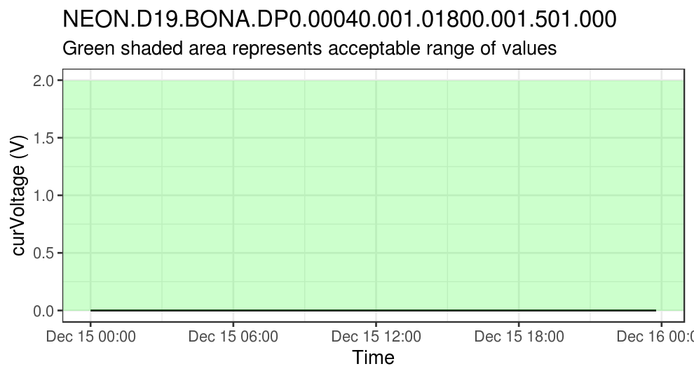

### CARI:

**Photosynthetically Active Radiation at Water Surface**: - Stream failure (*inPAR*) at stream sensor location 1 [2019-10-18*] - Stream failure (*inPAR*) at stream sensor location 2 [2019-10-18*]

## D20

### PUUM:

**Relative humidity**: - Assembly failure at meas. level 6 [2019-12-01*]

**Atmospheric CO2 Isotope**: - Stream failure (*fwMoleCO2*) at hut [2019-12-07*] - Stream failure (*percentFwMoleH2O*) at hut [2019-12-07*] - Stream failure (*d13CO2*) at hut [2019-12-07*]

NEON fun fact: Yesterday (2019-12-15), D06 had the highest average uptime! (99%)

*To unsubscribe from these reports, please email Robert Lee at rlee@battelleecology.org. Please specify if you’d like to modify your subscription or completely unsubscribe.*